# Impact of Severe Weather Events on U.S. Population Health and Economy

Kevin Tham

April 18, 2018

## Introduction

Storms and other severe weather events can cause both public health and economic problems for communities and municipalities. Many severe events can result in fatalities, injuries, and property damage, and preventing such outcomes to the extent possible is a key concern.

This project involves exploring the U.S. National Oceanic and Atmospheric Administration’s (NOAA) storm database. This database tracks characteristics of major storms and weather events in the United States, including when and where they occur, as well as estimates of any fatalities, injuries, and property damage.

## Synopsis

We address the following questions through analysis of the U.S. National Oceanic and Atmospheric Administration (NOAA) Storm Database:

1. Across the United States, which types of events (as indicated in the EVTYPE variable) are most harmful with respect to population health?
2. Across the United States, which types of events have the greatest economic consequences?

The important variables from the dataset are picked out and cleaned, and from there the top 10 weather events impacting population health and economy are picked out. It is deduced from the results that tornadoes have the greatest impact on population health while flooding has overall the largest impact on the economy.

## Data Processing

First, we load the required packages and install them first if they are not available:

```r
if (!require("pacman")) install.packages("pacman")
pacman::p_load(knitr, dplyr, ggplot2, tidyr, hexbin, timeDate, grid, gridExtra, gtable)
```

Next we download and unzip the data file to read in the dataset:

```r
destfile <- 'repdata%2Fdata%2FStormData.csv.bz2'
url <- 'https://d396qusza40orc.cloudfront.net/repdata%2Fdata%2FStormData.csv.bz2'

if (!file.exists(destfile))
  download.file(url, destfile, method = "auto")

df <- read.csv(destfile)
```

We will explore the dataset using the `head()` and `str()` functions:

```r
head(df)
```

```
##   STATE__           BGN_DATE BGN_TIME TIME_ZONE COUNTY COUNTYNAME STATE
## 1       1  4/18/1950 0:00:00     0130       CST     97     MOBILE    AL
## 2       1  4/18/1950 0:00:00     0145       CST      3    BALDWIN    AL
## 3       1  2/20/1951 0:00:00     1600       CST     57    FAYETTE    AL
## 4       1   6/8/1951 0:00:00     0900       CST     89    MADISON    AL
## 5       1 11/15/1951 0:00:00     1500       CST     43    CULLMAN    AL
## 6       1 11/15/1951 0:00:00     2000       CST     77 LAUDERDALE    AL
##    EVTYPE BGN_RANGE BGN_AZI BGN_LOCATI END_DATE END_TIME COUNTY_END
## 1 TORNADO         0                                               0
## 2 TORNADO         0                                               0
## 3 TORNADO         0                                               0
## 4 TORNADO         0                                               0
## 5 TORNADO         0                                               0
## 6 TORNADO         0                                               0
##   COUNTYENDN END_RANGE END_AZI END_LOCATI LENGTH WIDTH F MAG FATALITIES
```

[output cut: 20 more lines]

```r
str(df)
```

```
## 'data.frame':    902297 obs. of  37 variables:
##  $ STATE__   : num  1 1 1 1 1 1 1 1 1 1 ...
##  $ BGN_DATE  : Factor w/ 16335 levels "1/1/1966 0:00:00",..: 6523 6523 4242 11116 2224 2224 2260 383 3980 3980 ...
##  $ BGN_TIME  : Factor w/ 3608 levels "00:00:00 AM",..: 272 287 2705 1683 2584 3186 242 1683 3186 3186 ...
##  $ TIME_ZONE : Factor w/ 22 levels "ADT","AKS","AST",..: 7 7 7 7 7 7 7 7 7 7 ...
##  $ COUNTY    : num  97 3 57 89 43 77 9 123 125 57 ...
##  $ COUNTYNAME: Factor w/ 29601 levels "","5NM E OF MACKINAC BRIDGE TO PRESQUE ISLE LT MI",..: 13513 1873 4598 10592 4372 10094 1973 23873 24418 4598 ...
##  $ STATE     : Factor w/ 72 levels "AK","AL","AM",..: 2 2 2 2 2 2 2 2 2 2 ...
##  $ EVTYPE    : Factor w/ 985 levels "   HIGH SURF ADVISORY",..: 834 834 834 834 834 834 834 834 834 834 ...
##  $ BGN_RANGE : num  0 0 0 0 0 0 0 0 0 0 ...
##  $ BGN_AZI   : Factor w/ 35 levels "","  N"," NW",..: 1 1 1 1 1 1 1 1 1 1 ...
##  $ BGN_LOCATI: Factor w/ 54429 levels ""," Christiansburg",..: 1 1 1 1 1 1 1 1 1 1 ...
##  $ END_DATE  : Factor w/ 6663 levels "","1/1/1993 0:00:00",..: 1 1 1 1 1 1 1 1 1 1 ...
##  $ END_TIME  : Factor w/ 3647 levels ""," 0900CST",..: 1 1 1 1 1 1 1 1 1 1 ...
##  $ COUNTY_END: num  0 0 0 0 0 0 0 0 0 0 ...
```

[output cut: 23 more lines]

There are many variables present in this dataset, not all of which will be relevant to our analysis. We recap our goal:

1. To find out which **EVTYPE**(-s) is most harmful to **population health** across the US
2. To find out which **EVTYPE**(-s) have the greatest **economic consequences**

Therefore, we will narrow down the number of variables to those that are related to **EVTYPE**, **population health** and **economic consequences**.

Population health:

- `FATALITIES`
- `INJURIES`

Economic consequences:

- `PROPDMG`
- `PROPDMGEXP`
- `CROPDMG`
- `CROPDMGEXP`

We will select these variables from the original dataset in addition to `EVTYPE` for obvious reasons, and `STATE__` in order to analyse the spatial variation of population health and economic consequences:

```r
df_filtered <- select(df, EVTYPE, STATE__, FATALITIES, INJURIES,
                      PROPDMG, PROPDMGEXP, CROPDMG, CROPDMGEXP)
```

The proportion of missing values in the dataframe is first determined for the relevant variables:

```r
mean(is.na(df_filtered))
```

```
## [1] 0
```

Surprisingly there is a complete absence of missing variables.

By examining the variable `EVTYPE` (output supressed),

```r
unique(df_filtered$EVTYPE)
```

it is clear that there are many duplicates, errors and variants present in the variable `EVTYPE`. Therefore we will proceed by cleaning up this variable, using regular expressions to substitute variable names with the correct variable.

```r
event <- df_filtered$EVTYPE
event <- gsub('.*TSTM.*', 'THUNDERSTORM WIND', event, ignore.case=TRUE)
event <- gsub('.*THUNDER.*', 'THUNDERSTORM WIND', event, ignore.case=TRUE)
event <- gsub('.*THUND.*', 'THUNDERSTORM WIND', event, ignore.case=TRUE)
event <- gsub('.*micro.*', 'THUNDERSTORM WIND', event, ignore.case=TRUE)
event <- gsub('.*SPOUT.*', 'WATERSPOUT', event, ignore.case=TRUE)
event <- gsub('.*TORNADO.*', 'TORNADO', event, ignore.case=TRUE)
event <- gsub('^HIGH WIND.*', 'HIGH WIND', event, ignore.case=TRUE)
event <- gsub('.*AVALANCHE.*', 'AVALANCHE', event, ignore.case=TRUE)
event <- gsub('.*BLIZZARD.*', 'BLIZZARD', event, ignore.case=TRUE)
event <- gsub('.*SNOW.*', 'HEAVY SNOW', event, ignore.case=TRUE)
event <- gsub('.*HURRICANE.*', 'HURRICANE/TYPHOON', event, ignore.case=TRUE)
event <- gsub('.*TYPHOON.*', 'HURRICANE/TYPHOON', event, ignore.case=TRUE)
event <- gsub('.*HEAT.*', 'HEAT', event, ignore.case=TRUE)
event <- gsub('.*HOT.*', 'HEAT', event, ignore.case=TRUE)
event <- gsub('.*WARM.*', 'HEAT', event, ignore.case=TRUE)
event <- gsub('.*HIGH TEMP.*', 'HEAT', event, ignore.case=TRUE)
event <- gsub('.*COLD.*', 'EXTREME COLD/WIND CHILL', event, ignore.case=TRUE)
event <- gsub('.*HAIL.*', 'HAIL', event, ignore.case=TRUE)
event <- gsub('.*flash.flood.*', 'FLASH FLOOD', event, ignore.case=TRUE)
event <- gsub('.*flash.*', 'FLASH FLOOD', event, ignore.case=TRUE)
event <- gsub('.*LIGHTNING.*', 'LIGHTNING', event, ignore.case=TRUE)
event <- gsub('(?<!FLASH )FLOOD.*', 'FLOOD', event, ignore.case=TRUE, perl=TRUE)
event <- gsub('.*FLOOD.*', 'FLOOD', event, ignore.case=TRUE)
event <- gsub('.*FUNNEL.*', 'FUNNEL CLOUD', event, ignore.case=TRUE)
event <- gsub('.*FIRE.*', 'WILDFIRE', event, ignore.case=TRUE)
event <- gsub('.*TROPICAL STORM.*', 'TROPICAL STORM', event, ignore.case=TRUE)
event <- gsub('.*CURRENT.*', 'RIP CURRENT', event, ignore.case=TRUE)
event <- gsub('.*DRY.*', 'DROUGHT', event, ignore.case=TRUE)
event <- gsub('(?<!FREEZING )RAIN.*', 'HEAVY RAIN', event, ignore.case=TRUE, perl=TRUE)
event <- gsub('.*RAIN.*', 'HEAVY RAIN', event, ignore.case=TRUE)
event <- gsub('.*dust.*', 'DUST STORM', event, ignore.case=TRUE)
#table(grep('tornado',event,ignore.case=TRUE,value=TRUE, perl=TRUE))
#unique(event)

df_filtered$EVTYPE <- event
```

Having completed the cleaning of the data, we will split the dataset into two parts, one to determine the effect of these weather events on human health and the other to determine their effect on the economy. The portion related to human health is then further split into two portions, one describing human fatalities and one describing human injuries.

```r
health <- df_filtered %>%
  select(EVTYPE, FATALITIES, INJURIES) %>%
  group_by(EVTYPE) %>%
  summarise_all(funs(sum))

fatalities <- health %>%
  select(EVTYPE, FATALITIES) %>%
  arrange(desc(FATALITIES)) %>%
  top_n(10)

injuries <- health %>%
  select(EVTYPE, INJURIES) %>%
  arrange(desc(INJURIES)) %>%
  top_n(10)
```

Next we can examine the variables `PROPDMGEXP` and `CROPDMGEXP`:

```r
economic <- df_filtered %>% select(EVTYPE, PROPDMG, PROPDMGEXP, CROPDMG, CROPDMGEXP)
unique(economic$PROPDMGEXP)
```

```
##  [1] K M   B m + 0 5 6 ? 4 2 3 h 7 H - 1 8
## Levels:  - ? + 0 1 2 3 4 5 6 7 8 B h H K m M
```

```r
unique(economic$CROPDMGEXP)
```

```
## [1]   M K m B ? 0 k 2
## Levels:  ? 0 2 B k K m M
```

The variables `PROPDMGEXP` and `CROPDMGEXP` denote the exponent (hundreds, thousands, millions etc.) that is meant to be multiplied with `PROPDMG` and `CROPDMG` respectively in order to obtain the actual values of property and crop damage. Therefore in order to proceed it is required to transform the values under `PROPDMGEXP` and `CROPDMGEXP` to their actual numerical values.

```r
economic$PROPDMGEXP <- with(economic, ifelse(PROPDMGEXP=='H'|PROPDMGEXP=='h', 1e2,
                                      ifelse(PROPDMGEXP=='K'|PROPDMGEXP=='k', 1e3,
                                      ifelse(PROPDMGEXP=='M'|PROPDMGEXP=='m', 1e6,
                                      ifelse(PROPDMGEXP=='B'|PROPDMGEXP=='b', 1e9,
                                      ifelse(grepl('[0-8]',PROPDMGEXP), 1e1,
                                      ifelse(PROPDMGEXP=='+', 1e0, 0)))))))

economic$CROPDMGEXP <- with(economic, ifelse(CROPDMGEXP=='H'|CROPDMGEXP=='h', 1e2,
                                      ifelse(CROPDMGEXP=='K'|CROPDMGEXP=='k', 1e3,
                                      ifelse(CROPDMGEXP=='M'|CROPDMGEXP=='m', 1e6,
                                      ifelse(CROPDMGEXP=='B'|CROPDMGEXP=='b', 1e9,
                                      ifelse(grepl('[0-8]',CROPDMGEXP), 1e1,
                                      ifelse(CROPDMGEXP=='+', 1e0, 0)))))))

economic$PROPDMG <- economic$PROPDMG * economic$PROPDMGEXP
economic$CROPDMG <- economic$CROPDMG * economic$CROPDMGEXP
```

Similar to before, the dataset `economic` is split into two parts, one to describe property damage and the other to describe crop damage:

```r
economic <- economic %>%
  select(EVTYPE, PROPDMG, CROPDMG) %>%
  group_by(EVTYPE) %>%
  summarise_all(funs(sum))

propdmg <- economic %>%
  select(EVTYPE, PROPDMG) %>%
  arrange(desc(PROPDMG)) %>%
  top_n(10)

cropdmg <- economic %>%
  select(EVTYPE, CROPDMG) %>%
  arrange(desc(CROPDMG)) %>%
  top_n(10)
```

Finally we express the prop and property damages in the billions for easy viewing:

```r
propdmg$PROPDMG <- round(propdmg$PROPDMG / 1e9, 2)
cropdmg$CROPDMG <- round(cropdmg$CROPDMG / 1e9, 2)
```

With these steps complete, we are ready to present our results.

## Results

### Impact of Weather Events on US Population Health

We select the top 10 event types that contribute the most harm to population health, and show their impact on the number of injuries and fatalities below in Table 1, 2 and Figure 1.

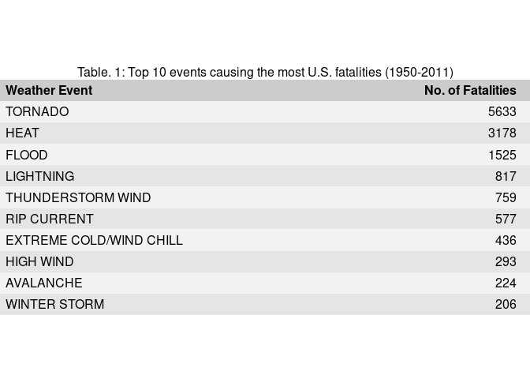

```r
# function to return index of all column grobs
find_column <- function(table, col, name="core-fg") {
  l <- table$layout
  which(l$l==col & l$name==name)
}

# function to justify column left or right
justcol <- function(textgroblist, hjust, x) {
  i = 0
  for (textgrob in textgroblist) {
    i = i + 1
    textgroblist[[i]]$hjust <- hjust
    textgroblist[[i]]$x <- unit(x, 'npc')
  }
  textgroblist
}

ttheme <- ttheme_default(core=list(bg_params=list(col=NA)),
                         colhead=list(bg_params=list(col=NA)))

fat_table <- tableGrob(fatalities, row=NULL, cols=c('Weather Event', 'No. of Fatalities'),
                                                    theme=ttheme)

fat_table$widths <- unit(rep(1/ncol(fat_table), ncol(fat_table)), "npc")

row1_ind <- c(find_column(fat_table, 1), find_column(fat_table, 1, name='colhead-fg'))
row2_ind <- c(find_column(fat_table, 2), find_column(fat_table, 2, name='colhead-fg'))

fat_table$grobs[row1_ind] <- justcol(fat_table$grobs[row1_ind], 0, 0.02)
fat_table$grobs[row2_ind] <- justcol(fat_table$grobs[row2_ind], 1, 0.95)

plottitle <- textGrob(
  'Table. 1: Top 10 events causing the most U.S. fatalities (1950-2011)', just='centre')
width <- max(fat_table$layout$r)
fat_table <- gtable_add_rows(fat_table, grobHeight(plottitle)+unit(2,"mm"), pos=0)
fat_table <- gtable_add_grob(fat_table, plottitle, 1, 1, r=width)

grid.draw(fat_table)
```

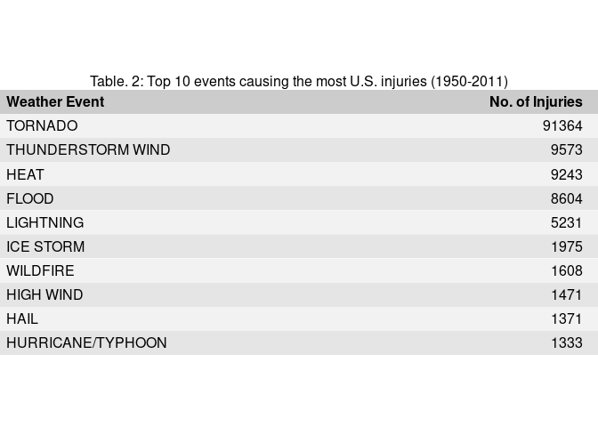

```r
inj_table <- tableGrob(injuries, row=NULL, cols=c('Weather Event', 'No. of Injuries'),
                       theme=ttheme)

inj_table$widths <- unit(rep(1/ncol(inj_table), ncol(inj_table)), "npc")

row1_ind <- c(find_column(inj_table, 1), find_column(inj_table, 1, name='colhead-fg'))
row2_ind <- c(find_column(inj_table, 2), find_column(inj_table, 2, name='colhead-fg'))

inj_table$grobs[row1_ind] <- justcol(inj_table$grobs[row1_ind], 0, 0.02)
inj_table$grobs[row2_ind] <- justcol(inj_table$grobs[row2_ind], 1, 0.95)

plottitle <- textGrob(
  'Table. 2: Top 10 events causing the most U.S. injuries (1950-2011)', just='centre')
width <- max(inj_table$layout$r)
inj_table <- gtable_add_rows(inj_table, grobHeight(plottitle)+unit(2,"mm"), pos=0)
inj_table <- gtable_add_grob(inj_table, plottitle, 1, 1, r=width)
grid.draw(inj_table)
```

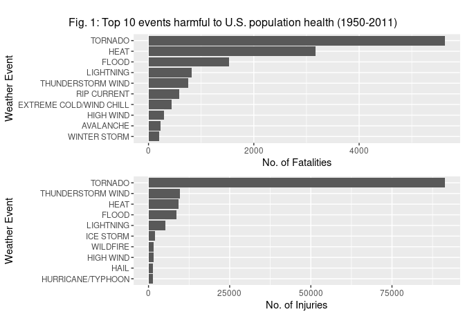

```r
h1 <- ggplot(fatalities, aes(x=reorder(EVTYPE, FATALITIES), y=FATALITIES)) +
  geom_bar(stat="identity") + theme(aspect.ratio=1.) + coord_flip() +
  labs(x="Weather Event", y="No. of Fatalities")
h2 <- ggplot(injuries, aes(x=reorder(EVTYPE, INJURIES), y=INJURIES)) +
  geom_bar(stat="identity") + theme(aspect.ratio=1.) + coord_flip() +
  labs(x="Weather Event", y="No. of Injuries")

g1 <- ggplotGrob(h1)
g2 <- ggplotGrob(h2)
plottitle <- textGrob(
  'Fig. 1: Top 10 events harmful to U.S. population health (1950-2011)', just='centre')

g1$widths[4] <- unit(3,"null")
g <- gtable_rbind(g1, g2, size='max')
g <- gtable_add_rows(g, grobHeight(plottitle)+unit(2,"mm"), pos=0)
g <- gtable_add_grob(g, plottitle, 1, 1, r=7)

grid.newpage()
grid.draw(g)
```

It is clear from Figure 1 that tornadoes in the U.S. have contributed to by far the greatest numbers of both injuries and fatalities over the period of 1950-2011. Extreme heat events also have a big impact on the U.S. population, contributing to the second highest number of fatalities and third highest number of injuries.

### Impact of Weather Events on US Economy

Likewise, the top 10 event types that contribute the most damage to the U.S. economy are selected, and their impact on property and crop damage are shown below in Table 3, 4 and Figure 2.

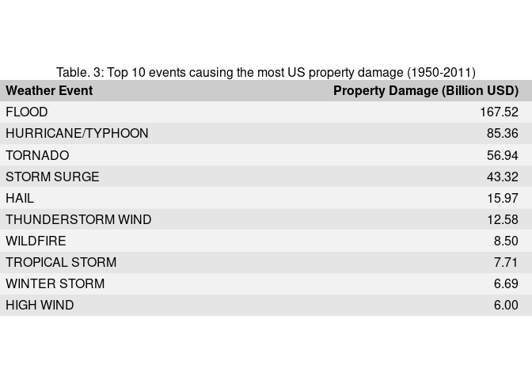

```r
propdmg_table <- tableGrob(propdmg, row=NULL,
                           cols=c('Weather Event', 'Property Damage (Billion USD)'),
                           theme=ttheme)

propdmg_table$widths <- unit(rep(1/ncol(propdmg_table), ncol(propdmg_table)), "npc")

row1_ind <- c(find_column(propdmg_table, 1), find_column(propdmg_table, 1,
                                                         name='colhead-fg'))
row2_ind <- c(find_column(propdmg_table, 2), find_column(propdmg_table, 2,
                                                         name='colhead-fg'))

propdmg_table$grobs[row1_ind] <- justcol(propdmg_table$grobs[row1_ind], 0, 0.02)
propdmg_table$grobs[row2_ind] <- justcol(propdmg_table$grobs[row2_ind], 1, 0.95)

plottitle <- textGrob(
  'Table. 3: Top 10 events causing the most US property damage (1950-2011)', just='centre')
width <- max(propdmg_table$layout$r)
propdmg_table <- gtable_add_rows(propdmg_table, grobHeight(plottitle)+unit(2,"mm"), pos=0)
propdmg_table <- gtable_add_grob(propdmg_table, plottitle, 1, 1, r=width)

grid.draw(propdmg_table)
```

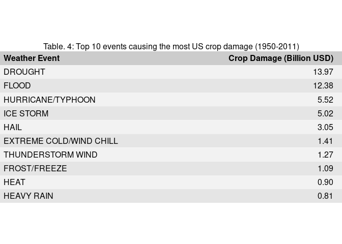

```r
cropdmg_table <- tableGrob(cropdmg, row=NULL,
                       cols=c('Weather Event', 'Crop Damage (Billion USD)'),
                       theme=ttheme)

cropdmg_table$widths <- unit(rep(1/ncol(cropdmg_table), ncol(cropdmg_table)), "npc")

row1_ind <- c(find_column(cropdmg_table, 1), find_column(cropdmg_table, 1,
                                                         name='colhead-fg'))
row2_ind <- c(find_column(cropdmg_table, 2), find_column(cropdmg_table, 2,
                                                         name='colhead-fg'))

cropdmg_table$grobs[row1_ind] <- justcol(cropdmg_table$grobs[row1_ind], 0, 0.02)
cropdmg_table$grobs[row2_ind] <- justcol(cropdmg_table$grobs[row2_ind], 1, 0.95)

plottitle <- textGrob(
  'Table. 4: Top 10 events causing the most US crop damage (1950-2011)', just='centre')
width <- max(cropdmg_table$layout$r)
cropdmg_table <- gtable_add_rows(cropdmg_table, grobHeight(plottitle)+unit(2,"mm"), pos=0)
cropdmg_table <- gtable_add_grob(cropdmg_table, plottitle, 1, 1, r=width)

grid.draw(cropdmg_table)
```

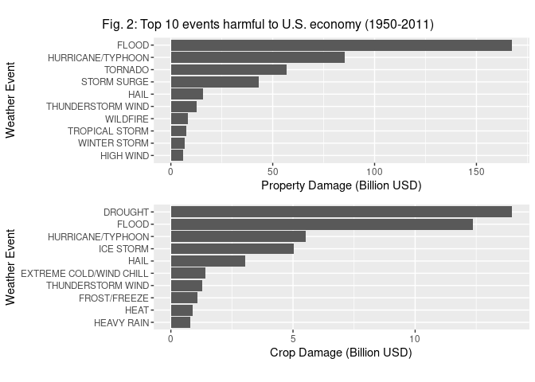

```r
l1 <- ggplot(propdmg, aes(x=reorder(EVTYPE, PROPDMG), y=PROPDMG)) +
  geom_bar(stat="identity") + theme(aspect.ratio=1.) + coord_flip() +
  labs(x="Weather Event", y="Property Damage (Billion USD)")
l2 <- ggplot(cropdmg, aes(x=reorder(EVTYPE, CROPDMG), y=CROPDMG)) +
  geom_bar(stat="identity") + theme(aspect.ratio=1.) + coord_flip() +
  labs(x="Weather Event", y="Crop Damage (Billion USD)")

k1 <- ggplotGrob(l1)
k2 <- ggplotGrob(l2)
plottitle2 <- textGrob(
  'Fig. 2: Top 10 events harmful to U.S. economy (1950-2011)', just='centre')

k1$widths[4] <- unit(3,"null")
k <- gtable_rbind(k1, k2, size='max')
k <- gtable_add_rows(k, grobHeight(plottitle2)+unit(2,"mm"), pos=0)
k <- gtable_add_grob(k, plottitle2, 1, 1, r=7)

grid.newpage()
grid.draw(k)
```

We can see from Figure 2 that flooding has a large negative impact on the U.S. economy, causing the largest amount of property damage and second largest amount of crop damage. Meanwhile, drought is the largest factor contributing to crop damage. This is not surprising as crop growth has always been dependent on the weather and the presence of rain. It is interesting to note that tornadoes, while still causing significant property damage (third on the list), is not among the top ten weather events contributing to crop damage.